# The Sports Shack: Revenue Optimization Analysis

### Diagnostic Checks (Assumptions)

We checked the validity of our Regression model using standard diagnostic plots.

**1. Normality of Residuals (Q-Q Plot):** The residuals largely follow the line, indicating normality is satisfied.

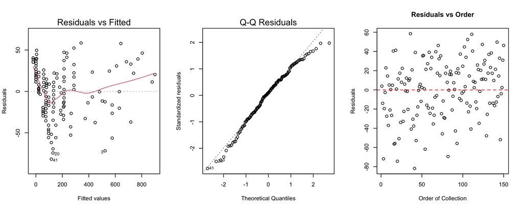

```r
par(mfrow=c(1,3))
plot(final_model, which = 1)
plot(final_model, which = 2)

plot(final_model$residuals,
     main = "Residuals vs Order",
     ylab = "Residuals",
     xlab = "Order of Collection")
abline(h = 0, col = "red", lty = 2)
```

```r
par(mfrow=c(1,1))
```

### Limitations & Validity

While the analysis provides strong evidence for a specific marketing strategy, a few limitations should be noted:

1. **Seasonality is a Proxy:** We grouped data by “Season” (e.g., Winter), but we do not have specific dates. A more granular analysis by month might reveal that the “Winter” spike is solely driven by the weeks before Christmas, rather than the whole season.
2. **Satisfaction Score Subjectivity:** The satisfaction score (1-10) is subjective. A “7” from a teenager might mean something different than a “7” from a Dad. However, the strong correlation ($p < 0.001$) suggests it is still a valid predictor.
3. **Causality:** While we see a correlation between Satisfaction and Spend, we cannot prove causality. It is possible that customers who spend more *become* more satisfied because they bought products they like, rather than high satisfaction *causing* them to spend more.

### The Data

Below is the raw transactional data used for this analysis.

```r
datatable(select(sports_data, -Color), options = list(pageLength = 5))
```

|  | TransactionID | Customer_Segment | Season | Marketing_Source | Items_In_Cart | Satisfaction_Score | Total_Spend |
| --- | --- | --- | --- | --- | --- | --- | --- |
| 1 | 1 | Teen | Summer | Instagram | 1 | 6 | 25.5 |
| 2 | 2 | Mom | Back-To-School | Radio | 3 | 8 | 120 |
| 3 | 3 | Coach | Spring | Referral | 8 | 10 | 450.75 |
| 4 | 4 | Teen | Summer | Instagram | 2 | 5 | 35 |
| 5 | 5 | Dad | Winter | Radio | 2 | 9 | 210 |
| 6 | 6 | College_Student | Back-To-School | Walk-In | 1 | 7 | 45 |
| 7 | 7 | Mom | Back-To-School | Instagram | 4 | 8 | 160.5 |
| 8 | 8 | Teen | Summer | Instagram | 1 | 5 | 15 |
| 9 | 9 | Coach | Back-To-School | Referral | 12 | 9 | 680 |
| 10 | 10 | Dad | Winter | Radio | 1 | 10 | 185 |

[output cut: 140 more lines]